# Global VDR Market Research Report

Comprehensive Market Analysis and Forecast (2024-2025)

Gayatri Samal

2024-09-08

### Global VDR Market Size Data

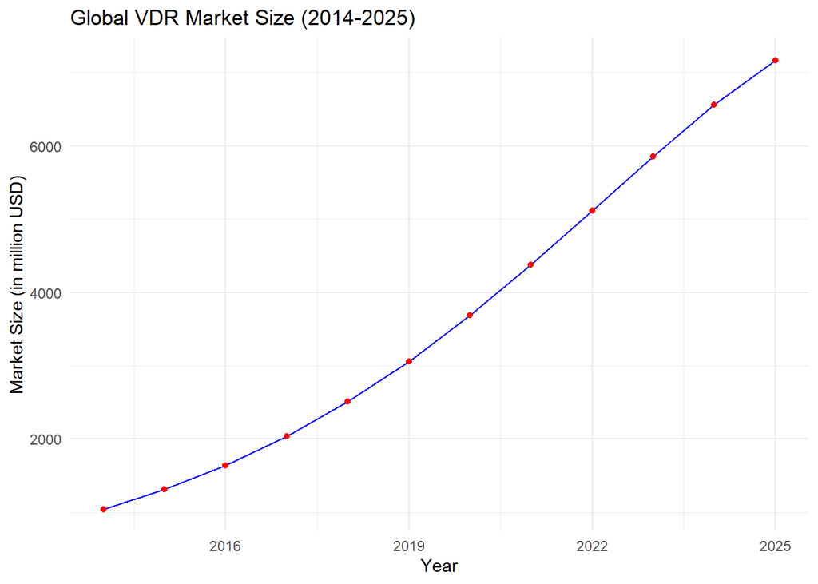

The plot shows a clear upward trend in the market size, indicating a consistent growth over the years.

### 2. **Regional Market Analysis (2014-2025)**

#### Key Insights:

- **North America Dominance:** The North American market, valued at USD 2,261.1 million by 2025, leads globally with a **CAGR of 13.7%**. This is driven by the early adoption of VDRs in industries like finance and legal.
- **Asia-Pacific Highest Growth:** The Asia-Pacific region is the fastest-growing, with a **CAGR of 15.1%**, fueled by digitalization trends in emerging economies like China and India.
- **Europe and Latin America:** Europe is set to grow at a **14.5% CAGR**, driven by the region’s focus on regulatory compliance and data protection, while Latin America, with a **14.0% CAGR**, shows consistent growth potential.

#### Implication:

- Companies should prioritize market penetration strategies in Asia-Pacific while maintaining strong positions in North America and Europe. Latin America offers an emerging opportunity, particularly for firms focusing on untapped potential.

### 3. **Component Analysis (2014-2025)**

#### Key Insights:

- **Software Dominates:** The software segment, expected to grow to USD 5,605.4 million by 2025, shows strong demand for robust, secure, and user-friendly VDR software, representing a **CAGR of 14.1%**.
- **Service Segment:** The services segment is projected to grow at a faster rate (**14.7% CAGR**), highlighting the increasing importance of VDR-related services such as support, consulting, and customization.

#### Implication:

- Market players should invest in enhancing their software capabilities while expanding their service offerings to meet the growing demand for customer-centric solutions. Service innovations, like personalized onboarding and training, could provide a competitive edge.

### 4. **Deployment Mode Analysis (2014-2025)**

#### Key Insights:

- **Cloud Deployment Leads:** Cloud-based VDR solutions dominate the market, with a **CAGR of 14.0%** and growing to USD 5,749.5 million by 2025. This growth is driven by the flexibility, scalability, and cost-efficiency offered by cloud solutions.
- **On-Premises:** Despite its smaller share, the on-premises segment shows a faster growth rate (**15.1% CAGR**), driven by industries with stringent data security regulations, such as healthcare and finance.

#### Implication:

- Companies should focus on developing scalable, secure cloud-based VDR solutions. For industries with strict compliance requirements, offering hybrid solutions combining cloud and on-premises options will be crucial.

### 5. **Business Function Analysis (2014-2025)**

#### Key Insights:

- **Finance and Legal Lead:** Finance (USD 2,779.7 million by 2025) and Legal (USD 2,385.5 million by 2025) dominate the use of VDRs, driven by a need for secure data exchange in mergers and acquisitions, due diligence, and regulatory compliance.
- **Marketing and Sales Lag:** Marketing and Sales functions represent a smaller share, growing at a slower **13.5% CAGR**, indicating a lower reliance on VDRs compared to other business functions.

#### Implication:

- VDR providers should tailor their offerings to meet the specific needs of finance and legal professionals, incorporating advanced security features and compliance tools. They should also explore niche opportunities in workforce management and sales.

### 6. **Organization Size Analysis (2014-2025)**

#### Key Insights:

- **Large Enterprises:** Large enterprises are the primary users of VDRs, with an expected market size of USD 4,967.8 million by 2025, growing at **13.9% CAGR**.
- **SMEs:** The small and medium-sized enterprises (SMEs) segment is growing faster at **14.9% CAGR**, reflecting increased adoption among smaller organizations as VDRs become more affordable and accessible.

#### Implication:

- While large enterprises remain a key market, expanding into the SME segment represents a significant growth opportunity. Tailored pricing models, user-friendly interfaces, and cloud-based solutions will be important for gaining traction in the SME market.

### 7. **Industry Vertical Analysis (2014-2025)**

#### Key Insights:

- **Telecom & IT Lead:** Telecom and IT, with a market size of USD 1,534.4 million by 2025, dominate the VDR market, driven by high data exchange volumes and the need for secure communication.
- **Healthcare & Life Sciences:** The healthcare segment, with the highest **CAGR of 15.6%**, is rapidly adopting VDRs due to increasing regulatory demands and the need for secure patient data sharing.
- **BFSI and Manufacturing:** These verticals show consistent growth, driven by high regulatory requirements and secure data management needs.

#### Implication:

- Healthcare and IT will be key industries to target with industry-specific VDR solutions, especially solutions that cater to compliance and security needs. BFSI and manufacturing also present ongoing opportunities, especially for on-premises VDR deployments.

## Time Series Modeling

To forecast future market sizes, we convert the data into a time series object and apply various time series models.

### Augmented Dickey-Fuller Test

We perform the Augmented Dickey-Fuller (ADF) test to check for stationarity. If the p-value is greater than 0.05, the time series is non-stationary.

```
##
##  Augmented Dickey-Fuller Test
##
## data:  vdr_ts
## Dickey-Fuller = 1.8584, Lag order = 2, p-value = 0.99
## alternative hypothesis: stationary
```

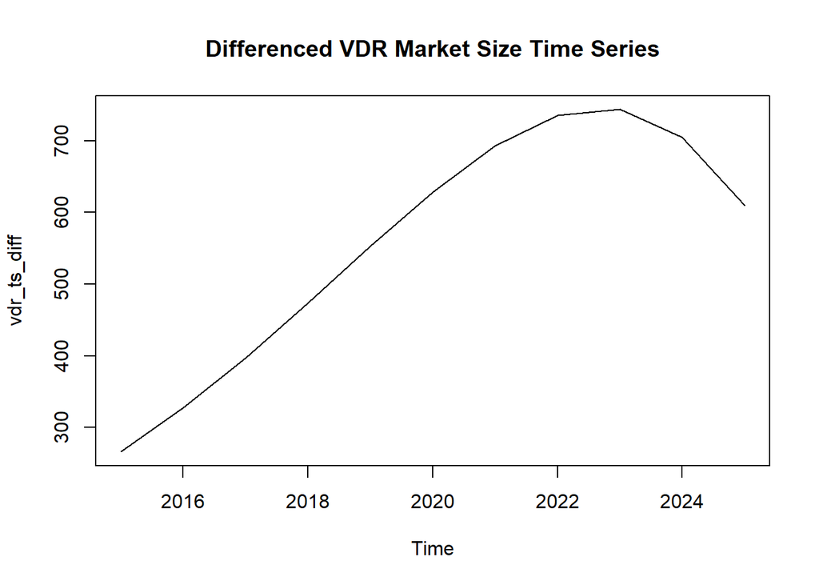

```
##
##  Augmented Dickey-Fuller Test
##
## data:  vdr_ts_diff
## Dickey-Fuller = -3.5769, Lag order = 2, p-value = 0.0532
## alternative hypothesis: stationary
```

## ARIMA Model

### Identifying ARIMA Parameters

Using Autocorrelation Function (ACF) and Partial Autocorrelation Function (PACF) plots to identify suitable ARIMA parameters.

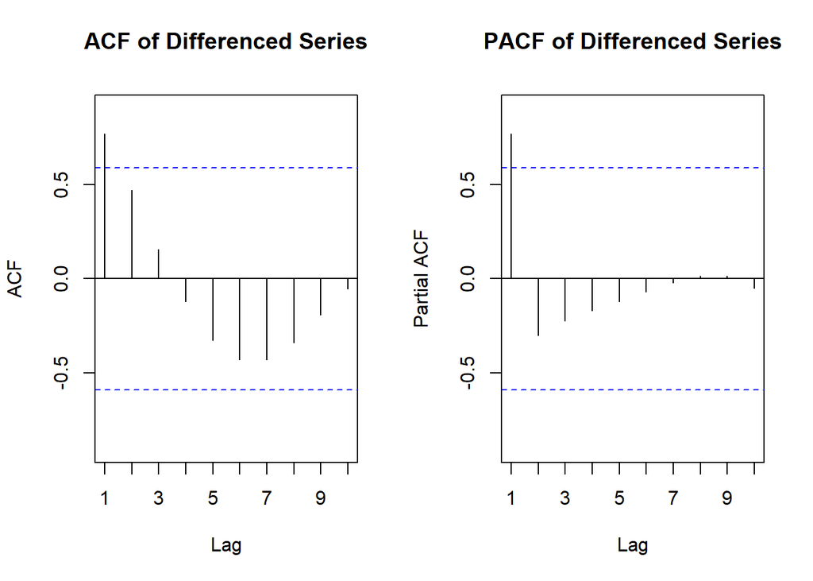

Fitting the ARIMA Model

```
## Series: vdr_ts
## ARIMA(1,2,0)
##
## Coefficients:
##          ar1
##       0.9245
## s.e.  0.0921
##
## sigma^2 = 882.9:  log likelihood = -48.54
## AIC=101.09   AICc=102.8   BIC=101.69
##
## Training set error measures:
##                     ME     RMSE     MAE       MPE      MAPE       MASE
## Training set -8.408347 25.73273 18.3757 0.0280508 0.4602422 0.03297112
##                   ACF1
## Training set 0.6975862
```

*Model Summary:* The `auto.arima` function suggests an ARIMA model with specific parameters based on the data.

Forecasting with ARIMA

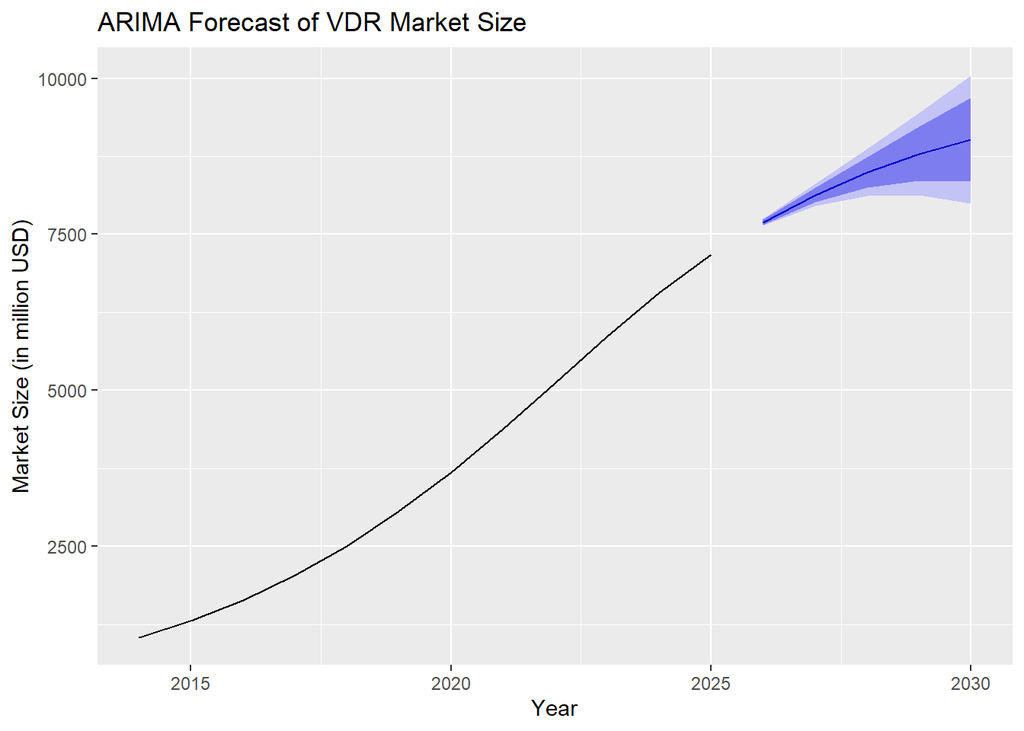

*Interpretation:* The ARIMA model forecasts a continued increase in market size over the next five years.

## SARIMA Model

Since the data does not exhibit clear seasonal patterns due to annual frequency, SARIMA may not be necessary. However, for demonstration purposes, we can still attempt to fit a SARIMA model.

```
## Series: vdr_ts
## ARIMA(1,2,0)
##
## Coefficients:
##          ar1
##       0.9245
## s.e.  0.0921
##
## sigma^2 = 882.9:  log likelihood = -48.54
## AIC=101.09   AICc=102.8   BIC=101.69
##
## Training set error measures:
##                     ME     RMSE     MAE       MPE      MAPE       MASE
## Training set -8.408347 25.73273 18.3757 0.0280508 0.4602422 0.03297112
##                   ACF1
## Training set 0.6975862
```

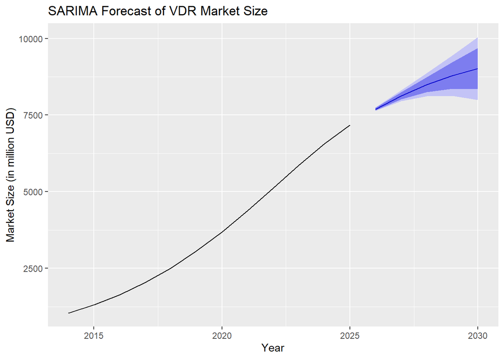

## Prophet Model

The Prophet model by Facebook is known for handling time series with strong trends and seasonality.

### Preparing Data for Prophet

Fitting the Prophet Model

Forecasting the Prophet Model

[interactive chart not shown]

*Interpretation:* The Prophet model predicts a continued growth trend, aligning with previous models.

All models suggest a similar upward trend, indicating confidence in the forecasted growth.

## Conclusion

The analysis of the global VDR market using ARIMA, SARIMA, and Prophet models indicates a strong and consistent growth trend over the next five years (2026-2030). The forecasts suggest that the market will continue to expand, driven by factors such as increased demand for secure data management solutions, technological advancements, and adoption across various industries.

The global VDR market shows robust growth, driven by demand for secure data sharing across industries, particularly in finance, legal, healthcare, and IT. The market is shifting towards cloud-based solutions, with growing demand for services and solutions tailored to smaller organizations. Companies operating in this space should focus on geographic expansion, cloud innovation, and vertical-specific solutions to remain competitive and capitalize on the market’s rapid growth trajectory.

**Recommendations:**

- **Strategic Investment:** Companies should consider investing in VDR technologies to capitalize on the growing market.
- **Market Expansion:** Focus on emerging markets, particularly in Asia Pacific and Latin America, where higher growth rates are expected.
- **Innovation:** Invest in research and development to offer advanced features that meet evolving customer needs.

**Note:** The forecasts provided are based on historical data up to 2025 and assume that current trends will continue. External factors such as economic shifts, technological breakthroughs, or regulatory changes could impact future market dynamics.